# Aerodynamics with Python: Flow over a Flat Plate

[figure not shown]

## Introduction

A flow over a flat plate is perhaps the easiest and the most useful and studied problem in Aerodynamics. Despite of its simplicity, no analytical solutions exist for calculating the boundary layer. Similarity solutions were found long time ago by Blasius and Falkner-Skan. They require to numerically solve non linear differential equations.Therefore, this notebook will also be useful to apply some of the tools available in python to solve these types of engineering ODEs

The main idea behind these series of notebooks is to present basic aerodynamics examples to and understand the basics of programming, and work with the equations to apply them to useful situations.

### Methodology

Object Orientated programming has been used to code the numerical solutions. Step by Step basic theory will be presented alongside the corresponding numerical solution coded in python.

There will different objects that will be created. Each object will have different attributes defining the main phisical properties of the object to solve the corresponding equations:

To solve a flow passing a flat plate 3 main objects have been used:

- Flat Plate Class : fp
- Free Stream Class : fs
- Boundary Layer Class : bl
  - Laminar boundary Layer: l_bl
  - Turbulent boundary Layer: t_bl
  - Transition boundary layer: l_t_bl

### Objectives

The main goal behind this analysis is to have a basic solution for a plate with different types of pressure gradients an suction velocities. This solution will be later used to apply viscosity corrections to potential solutions in later tutorials.

This code can be also used to compare basic solutions with experimental set of results or CFD solutions

## Packages Needed

```python
import numpy as np
import matplotlib.pyplot as plt
from scipy.integrate import odeint
```

## Problem Specification

[figure not shown]

### Freestream Class

A free-stream air flow $u_{e}$ at temperature $T$ and pressure $P$ flows over a flat plate of length $L$ at a temperature $T_{p}$.

FreeStream class, given velocity, temperature, pressure and a characteristic length, calculates the following quantities

Viscosity is calculated using Sutherland´s Law:

\begin{equation} \mu = \frac{1.458\cdot 10^{-6} \cdot T^{3/2}}{T + 110.4} \end{equation}

Ideal gas is assumed, so density is calculated as:

\begin{equation} \rho = \frac{P}{287 \cdot T} \end{equation}

The Reynolds number based on the carachterist lenght of the plate is:

\begin{equation} Re = \frac{u_{e} \cdot L}{\nu} \end{equation}

and Prandtl number:

\begin{equation} Pr = \frac{c_{p} \cdot \mu}{k} \end{equation}

where $c_{p} = 0.3 $ and $ k = 0.02 $ are thermal conductivity and specific heat for air.

```python
class freestream:

    def __init__(self,ue,L):

        self.ue         = ue     # Free stream veocity
        self.P          = 101325 # Pressure
        self.T          = 300    # Temperature
        self.k          = 0.02   # Air thermal conductivity
        self.cp         = 0.3    # Air constant specific heat

        self.L          = L      # Charasteristic Lenght

        # Viscosity Sutherland´s Law
        self.mu   = (1.458*10e-6 * self.T**(3/2)) / (self.T + 110.4)

        # Ideal Gas
        self.rho  = self.P/(287*self.T)

        # Kinematic Viscosity
        self.nu   = self.mu/self.rho

        # Prant number
        self.Pr   = self.cp*self.mu/self.k

        # Reynolds
        self.Re   = self.ue*self.L/self.nu


    def print_data(self,delta_est):

        print("ue =", self.ue, " m/s",
            " Re=" , round(self.Re,0)," Pr  = ", round(self.Pr,3),
            "delta ~ " , round(delta_est,5),"(m)")

ue = 10     # Free Stream Velocity
L  = 1      # Lenght of the plate (m)
Tp  = 300   # Plate Surface Temperature (K)

# Creation of a Free Stream
fs = freestream(ue,L)

# Estimation of boundary layer height
delta_est = L/(fs.Re)**0.5

# Print information
fs.print_data(delta_est)
```

```
ue = 10  m/s  Re= 63750.0  Pr  =  0.003 delta ~  0.00396 (m)
```

### Flat Plate Class

A mesh grid is used to discretize flat plate coordinates $x$ and $y$. It is recommended to use log-space distribution in x since it helps to visualize the logarithm shape of the boundary layer when it comes to plotting the results.

Additionally, non dimensional similarity parameter $\eta$, which will be introduced later is calculated as:

$$ \begin{equation} \eta = y \sqrt{\frac{u_{e} }{2\nu x}} \end{equation} $$

```python
class flat_plate:

    def __init__(self,L,Tp):

        self.L          = L     # Lenght of the plate (m)
        self.w          = 1     # Withd of the plate  (w)
        self.Tp         = Tp    # Surface Temperature (K)
        self.x,self.y   = [],[] # x, y grid vectors
        self.X,self.Y   = [],[] # X, Y Grid
        self.eta        = []    # eta
        self.ETA        = []    # ETA Grid

    def grid(self,delta_est,ue,nu):

        ## Grid Generation (By default grid is not generated)
        n_x = 500
        n_y = 500

        # Mesh X Grid
        self.x    = self.L*np.logspace(-5,0,n_x+1)
        #self.x    = np.linspace(0,self.L,1000)
        #self.x[0] = 10e-6

        # Mesh Y Grid boundary layer height
        self.y    = np.linspace(0,50*delta_est,n_y+1)

        ## Lineal Vector of etas
        self.eta    = np.linspace(0, 6, n_x+1)

        # Meshgrid
        self.X, self.Y   = np.meshgrid(self.x, self.y)

        # Non dimensional distance Meshgrid
        self.ETA    = (ue/((2)*nu*self.X))**0.5 * self.Y

# Creation of a flat plate
fp = flat_plate(L,Tp)

# Creation of the flat plate grid
fp.grid(delta_est,ue,fs.nu)
```

### Boundary Layer Class

A generic boundary layer class is going to be defined. This class is meant to be the parent class of different types of boundary layers. Although calculations are very different, there are several attributes, which are defined alongside the flat plate length, that are common to all boundary layers:

$ Re_{x}, \delta, \delta^{*}, \delta^{**},H, \tau_{w}, c_{f} $

Additionally, when these x-vectors are known, for all types of boundary layers, drag for both sides of the plate is always calculated as:

$$ \begin{equation} D = 2 \cdot w \int_{0}^{L} \tau_{w}(x) dx \end{equation} $$

and the drag coefficient is then calculated as:

$$ \begin{equation} C_{d} = \frac{2\cdot D}{\rho \cdot u_{e}^{2}\cdot w \cdot L} \end{equation} $$

```python
class boundary_layer:

	def __init__(self,*args):

		# X Values
		self.Rex,self.delta,self.delta_s,self.delta_ss,self.H,self.tw,self.cf = [],[],[],[],[],[],[]

	    # Drag
		self.Cd = 0

	    # Velocities
		self.u,self.v = [],[]

	def Drag(self,L,w,ue,rho,x):

		D  = 2 * w * np.trapz(self.tw, x)
		self.Cd = (2*D)/(rho*ue**2*w*L)
```

## Laminar Solution

Laminar solution can be obtained by using Blasius equation which is a nonlinear ODE which may be derived as a simplification of the Navier-Stokes equations for the particular case of stationary, incompressible boundary layer flows.

Introducing a stream function $ \Psi (x,y) $ defined as:

$$ \begin{equation} u = \frac{\partial \Psi }{\partial y}, v= -\frac{\partial \Psi}{\partial x} \end{equation} $$

He proposed the introduction of a similarity variable $ \eta $ and the non-dimensional stream function $ f $

$$ \begin{equation} \eta = \sqrt{\frac{U_{0} y}{2 \nu x}}, f(\eta)= \frac{ \Psi}{\sqrt{2 U_{0} \nu x}} \end{equation} $$

Obtaining the following ODE equation for the stream function f which will allow to calculate velocities, boundary layer properties and temperatures for all the boudary layer field over the plate:

$$ \begin{equation} f^{'''}(\eta) + f(\eta) \cdot f^{''}(\eta) = 0 \end{equation} $$

where the no slip condition $u = 0$ for $ y= 0$ will consequently correspond to $f^{'}(0) = 0 $ and $f^{'}(\eta) = u/U_{0} $ which corresponds to $f^{'}(\eta) \rightarrow 1 $ for $ \eta \rightarrow \infty $

### Numerical Solution: Shooting Method Class

To approach the problem of solving the boundary layer using Blasius functions a shooting method is needed. In order to match the condition at $\eta = \infty$ and $\theta = \infty$ a number of trials with different slopes ("shootings") are going to be used until the condition at $ \eta \rightarrow \infty $ is satisfied.

Python Scipy package provides solvers to automatically implement this method (BVP). However, for this particular problem, the error of the function at $\eta = \infty$ is quite sensitive to the initial guess used for different pressure gradients ($\beta$). Therefore a manual implementation of the soothing method has been coded so the error function can easily be plotted if needed and the right vector of guesses can be chosen.

```python
class shooting_method():

    def __init__(self):

        self.nmax       = 200       # Maximum number of iterations
        self.eps        = 10e-4     # Error Allowed
        self.s          = [10e-6,1]    # Guessed values
        self.p          = -1        # position of the guess in vector df/dx
        self.q          = 0         # position of the boundary value in vector f(inf)
        self.s_guesses  = np.linspace(0.3,5)

    def plot_error_function(self,df,x,f0,finf,args_list):
        phi = []
        for s_guess in self.s_guesses:
            f0[-1] = s_guess
            if len(args_list)== 0:
                f = odeint(df,f0,x)
            else:
                f = odeint(df,f0,x,args = args_list)

            phi.append(f[-1][self.q] - finf[self.q])

        fig1 = plt.figure(1)
        plt.plot(self.s_guesses,phi)
        plt.title('Error Phi-function for the Blasius equation shooting')
        plt.ylabel('phi')
        plt.xlabel('s')
        plt.xlim(0,5)
        plt.ylim(-1,4)
        plt.grid(b=True, which='both')

    def error_function(self,phi0,phi1,s0,s1):
        if (abs(phi1-phi0)>0.0):
            return    -phi1 *(s1 - s0)/float(phi1 - phi0)
        else:
            return 0.0

    def first_guess(self,df,x,f0,finf,args_list):

        f0[self.p]  = self.s[0]

        if len(args_list)== 0:
            f = odeint(df,f0,x,tcrit=[x[0]])
        else:
            f = odeint(df,f0,x,args = args_list,tcrit=[x[0]])

        phi0 = f[-1][self.q] - finf[self.q]

        return phi0

    def execute(self,df,x,f0,finf,args_list):

        phi0 = self.first_guess(df,x,f0,finf,args_list)

        for n in range(self.nmax):

            # Updating next guess
            f0[self.p] = self.s[1]

            # Solving the differenctial equation
            if len (args_list)==0:
                f = odeint(df,f0,x,tcrit=[x[0]])
            else:
                f = odeint(df,f0,x,args = args_list,tcrit=[x[0]])

            # Computing Phi
            phi1 = f[-1][self.q] - finf[self.q]

            # Computing Error
            ds = self.error_function(phi0,phi1,self.s[0],self.s[1])

            # Updating initial guesses
            self.s[0]  = self.s[1]
            self.s[1]  += ds
            phi0 = phi1

            # Convergence criteria
            if (abs(ds)<=self.eps):
                break

        return f
```

### Laminar Boundary Layer Quantities

Using inheritance in python, a laminar boundary layer class can defined as a child of the main boundary layer class with more specific attributes.

This class implements functions and expressions to calculate the main properties use to compare different solutions. It takes into account the effect of a velocity suction parameter $v_w$ and a pressure gradient represented by Falkner-Skan wedge angle $\beta$. These 2 parameter will be later presented and explained.

After calculating Blasius functions, boundary layer expressions can be calculated as follows:

Horizontal velocity: $$ \begin{equation} \frac{u}{U} = f^{'}(\eta) \end{equation} $$

Vertical velocity: $$ \begin{equation} v = \sqrt{\frac{\nu u_e(x)}{(2-\beta)x}} \left[(1-\beta) \cdot \eta f^{'} - f(\eta) \right] \end{equation} $$

Boundary layer thickness: $$ \begin{equation} \delta = 0.994 \cdot f^{'}(\eta) \cdot x \sqrt{\frac{2}{Re_x}} \end{equation} $$

Boundary layer displacement thickness: $$ \begin{equation} \delta^{*} = x \sqrt{\frac{2-\beta}{Re_x}} \left[ \lim_{\eta \to \infty}\eta - f(\eta) \right] \end{equation} $$

Boundary layer momentum thickness $$ \begin{equation} \delta^{**} = x \sqrt{\frac{2-\beta}{Re_x}} \left[\frac{f^{''}(0,\beta) -\beta \lim_{\eta \to \infty}\eta - f(\eta)}{1+\beta} \right] \end{equation} $$

Shear Stress at the Wall:

$$ \begin{equation} \tau_{p} = \rho \cdot u_e^{2}(x) \cdot f^{''}(0,\beta) \sqrt{\frac{m+1}{2\cdot Re_x}} \end{equation} $$

the skin friction coefficient: $$ \begin{equation} c_{f} = \frac{\tau_p}{1/2 \cdot \rho \cdot u_e^{2}(x)} \end{equation} $$

and the Nusselt number:

$$ \begin{equation} Nu = \frac{q_p \cdot x}{k \cdot (T_p - T_{\infty})} = - \sqrt{\frac{Re_x}{2-\beta}} \left(\frac {d \theta}{d\eta}\right)_{\eta = 0} \end{equation} $$

```python
class laminar_boundary_layer(boundary_layer):

    def __init__(self,*args):

        super(laminar_boundary_layer,self).__init__(*args)

        self.vw  = args[-2]   # Suction ve3locity (m/s)

        # Initial Conditions for blasius and thermal equations
        self.f0        = [-(2**0.5)*self.vw,0,0]
        self.finf      = [0,1,0]
        self.theta0    = [1,0]
        self.thetainf  = [0,0]

        # Blasius solution
        self.f,self.fd,self.fdd = [],[],[]

        # Thermal Solution
        self.theta,self.thetad  = [],[]
        self.Nu =[]

        # Transition Point xt
        self.xt = 0

        # Falkner-Skan velocity
        self.ue = []

        # Auto_solve
        self.solve(*args)

    def fblasius(self,f,eta,beta):
        # Blasius differential equation for solving BL velocities
        return [f[1],f[2], -f[0]*f[2]-beta*(1-f[1]**2)]

    def fthermal(self,theta,x,Pr,f,eta):
    # Thermal differential equation for solving Temperature
        return [theta[1], -Pr*np.interp(x,eta,f)*theta[1]]

    def x_values(self,eta,beta,ue,rho,mu,nu,x,Pr):

        m = -beta/(beta-2)

        # Reynolds x
        self.Rex = self.ue*x/nu

        # Boundary layer thichkness with x
        self.delta = np.interp(0.994, self.fd, eta)*(2**0.5)*x/(self.Rex**0.5)

        # Boundary layer displacement thichkness with x
        # eta- f when eta = inf
        self.delta_s = x *((2-beta)/self.Rex)**0.5 * (self.f[-1]-self.f[-2])/(eta[-1]-eta[-2])

        # Boundary layer momentum thichkness with x
        self.delta_ss = x *((2-beta)/self.Rex)**0.5 *((self.fdd[0] - beta*(self.f[-1]-self.f[-2])/(eta[-1]-eta[-2]))/(1+beta))

        # Shape factor
        self.H = self.delta_s/self.delta_ss

        # Shear Stress
        self.tw = self.fdd[0]*mu*self.ue*(((self.ue)*(m+1))/(2*nu*x))**0.5
        self.tw[0] = self.tw[1] - ((self.tw[1]-self.tw[2])/(x[1]-x[2]))*x[1]

        # Friction coefficient with x
        self.cf = 2*(self.fdd[0]/(2**0.5))/(((2-beta)*self.Rex**0.5))
        self.cf[0] = self.cf[1] - ((self.cf[1]-self.cf[2])/(x[1]-x[2]))*x[1]

        # Nusselt number
        self.Nu = - (self.Rex/(2-beta))**0.5 * self.thetad[0]


        # x transition: Micjel Criteria (Only valid for Re between 4x10e5 - 7x10e6)
        for i in range(len(x)):
            if (self.delta_ss[i] * self.ue[i])/nu > 1.535 * ((self.ue[i]*x[i])/nu)**0.444:
                self.xt = x[i]
            break

    def grid_values(self,ETA,eta,beta,ue,nu,T,Tp,X):

        # U for each point of the grid
        self.u = self.ue * np.interp(ETA, eta, self.fd)

        # V for each point of the grid
        self.v = ((nu*self.ue)/((2-beta)*X))**0.5 * ((1-beta)*ETA*np.interp(ETA, eta, self.fd) - np.interp(ETA, eta, self.f))

        # Thermal non dimensional temperature
        THETA = np.interp(ETA,eta,self.theta)

        # Real Temperarure (K)
        Temp     = ((Tp - T) * THETA) + T

    def solve(self,fp,fs,vw,beta):

        # Free Stream values
        ue,rho,mu,nu,Re,Pr,T = fs.ue,fs.rho,fs.mu,fs.nu,fs.Re,fs.Pr,fs.T
        # Flat plate values
        L,w,Tp,x,X,Y,eta,ETA = fp.L,fp.w,fp.Tp,fp.x,fp.X,fp.Y,fp.eta,fp.ETA

        # Falkner-Skan velocity
        self.ue = ue*x**(-beta/(beta-2))

        ## Guessed values after seeing zeros at Phi plot
        sm   = shooting_method()
        sm.s = [beta+10e-2,2]
        sm.q = 1
        #sm.s_guesses  = np.linspace(beta+10e-25,5)
        #sm.plot_error_function(self.fblasius,eta,self.f0,self.finf,(beta,))

        ## Blasius Solution
        y = sm.execute(self.fblasius,eta,self.f0,self.finf,(beta,))
        self.f, self.fd, self.fdd = y[:,0], y[:,1], y[:,2]

        sm.s = [-0.1,0.1]
        sm.q = 0

        ## Thermal Solution
        y = sm.execute(self.fthermal,eta,self.theta0,self.thetainf,(Pr,self.f,eta,))
        self.theta, self.thetad = y[:,0], y[:,1]

        self.x_values(eta,beta,ue,rho,mu,nu,x,Pr)

        self.Drag(L,w,ue,rho,x)

        self.grid_values(ETA,eta,beta,ue,nu,T,Tp,X)
```

### Blasius Laminar solution

So, now all the classes needed for solving the problem are defined let´s get to create the first solution.

However, an additional class call "plotting" is going to be defined to above presenting excessive unnecessary code. This class can be found at the end of the notebook.

In this case, Blasius functions are normally plotted against non dimensional velocities and boundary layer thickness.

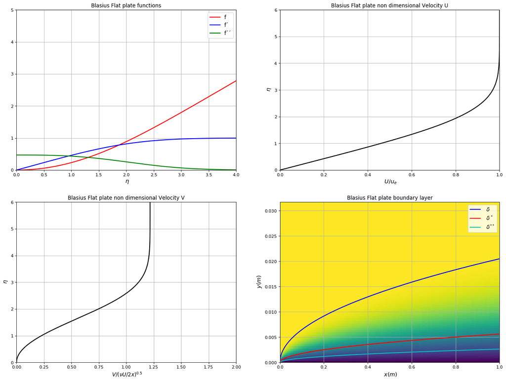

```python
# Creation of a laminar Boundary Layer
blasius_bl = laminar_boundary_layer(fp,fs,0,0)

# Plot
plotting.blasius (fp,fs,blasius_bl,delta_est)
```

In the figure shown above, classic Blasius solutions for a laminar case are presented. Keep an eye on how condition at the infinite has been satisfied

$$ \begin {equation} f^{} (\infty) = U/u_e = 1 \end {equation} $$

### Laminar Solution with Suction

Now, let´s say we want to control boundary layer thickness. Lots of investigations nowadays are focused on laminar boundary layer control in order to reduce drag.

So let´s to define a suction velocity to control boundary layer thickness. In order to keep thinhgs simple this velocity is assumed as constant alongside a porous wall flatplate.

So, by introducing a vertical velocity suction and blowing at the boundary for $ \eta = 0 $ the remaining condition for the equation is:

$$ \begin{equation} f(0) = -2 \cdot v^{*}_{\omega} \end{equation} $$

where $v^{*}_{\omega}$ is the non dimensional paramater that represents the vertical suction velocity:

$$ \begin{equation} v_{y=0} = v^{*}_{\omega} U \cdot \sqrt{\frac{\nu}{Ux}} \end{equation} $$

Therefore, it will be useful to compare different boundary layers against the laminar normal solution to see the effect of blowing and suction

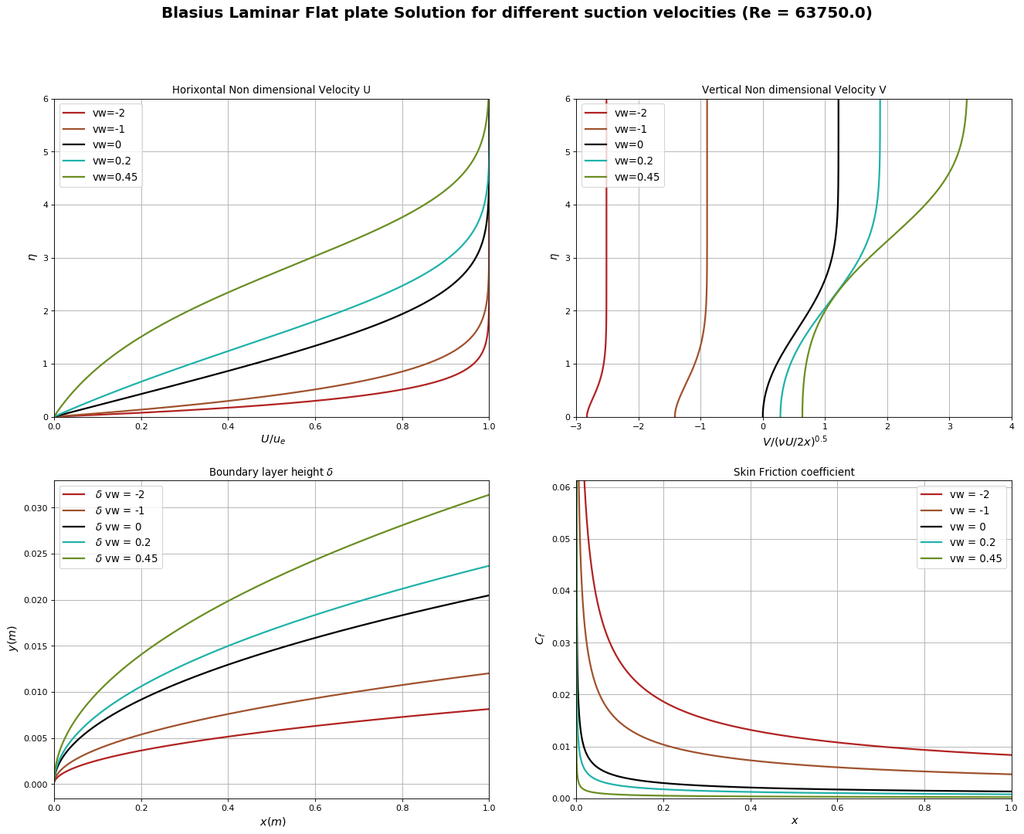

```python
# Suction Non Dimensional Velocities
vw = [-2,-1,0,0.2,0.45]

# Creation of a dictionary of boundary layers
laminars_bl = {}

for idx,VW in enumerate(vw):

    # Creation of a laminar boundary layer for each vw
    l_bl = laminar_boundary_layer(fp,fs,vw[idx],0)

    # Updating dictionary
    laminars_bl[str(vw[idx])]=l_bl

# Plot
plotting.laminar_suction_gradient(fp,fs,laminars_bl,delta_est,vw,"vw",2)
```

Non dimensional velocities, boundary layer thickness and skin friction coefficient have been plotted above.

Basically, the results show that introducing a negative velocity decreases boundary layer thickness and changes significantly velocity profiles $$U$$. This means that there is also going to be a direct impact on skin friction coefficient.

### Laminar Solution with adverse pressure gradient

After Blasius introduced the equation assuming a 0 pressure gradient, Falkner-Skan generalised the equation for some specific slip velocities $ u_{e}(x)$ or which can be though also as different exterior pressures $ p_{e}(x)$

He generelised Blasius equations for a wedge of angle $\beta$ where euler potencial solutions give the following free stream velocity:

$$ \begin{equation} u_{e}(x) = Ax^{m} \end{equation} $$

where $m$ and wedge angle $\beta$ are related through the following expression:

$$ \begin{equation} \beta = \frac{2m}{m+1} \end{equation} $$

therefore, introducing a wedge can be considered the same as introducing a pressure graddient parametrized by $m$ in Blasius equation :

$$ \begin{equation} \frac{1}{\rho} \frac{dp_{e}}{dx} = -u_{e}\frac{du_{e}}{dx} = - m \frac{u_{e}^{2}}{x} \end{equation} $$

Blasius Equation can be therefore generelaised for different values of $\beta$ using:

$$ \begin{equation} \eta = y \sqrt{\frac{u_{e}(x) }{(2-\beta) \nu x}}, f(\eta)= \frac{ \Psi}{\sqrt{(2-\beta) u_{e}(x) \nu x}} \end{equation} $$

Obtaining:

$$ \begin{equation} f^{'''}(\eta) + f(\eta) \cdot f^{''}(\eta) + \beta (1 -{f^{'}}^{2}) = 0 \end{equation} $$

with the same boundary conditions given before by: $f^{'}(0) = 0 $, $f^{'}(\eta_{\infty}) = 1 $, and $ f(0) = -2 \cdot v^{*}_{\omega}$

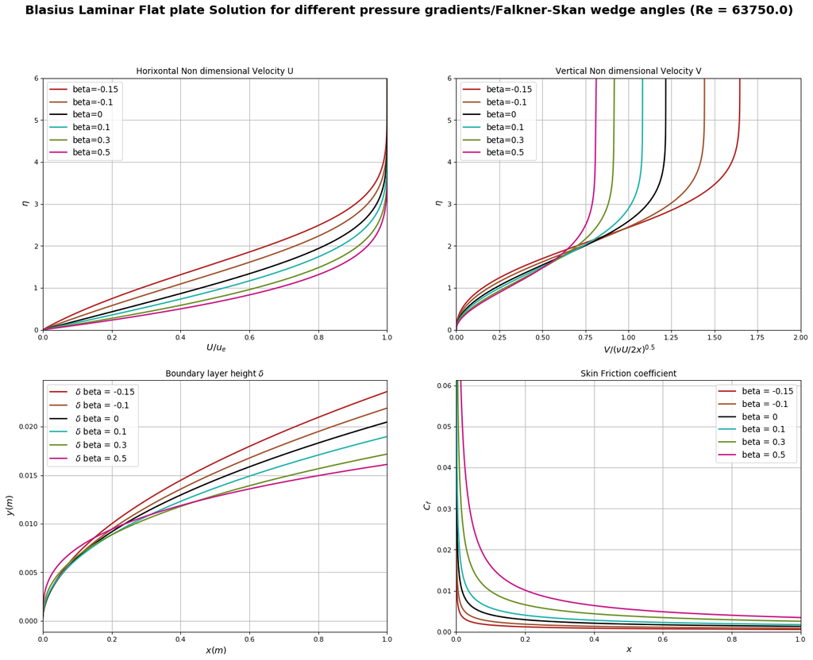

```python
# Falkner-Skan wedge angles (rad)
beta = [-0.15,-0.1,0,0.1,0.3,0.5]

# Creation of a dictionary of boundary layers
laminars_bl = {}

for idx,BETA in enumerate(beta):

    # Creation of a laminar boundary layer for each vw=0
    l_bl = laminar_boundary_layer(fp,fs,0,beta[idx])

    # Updating dictionary
    laminars_bl[str(beta[idx])]=l_bl

# Plot
plotting.laminar_suction_gradient(fp,fs,laminars_bl,delta_est,beta,"beta",3)
```

### Thermal Boundary Layer

Energy equation can be also written as an ODE using similarity parameter $\eta$:

$$ \begin{equation} \left(\frac {d^{2}\theta}{d\eta^{2}}\right) + Pr \cdot f(\eta) \left(\frac{d\theta}{d\eta}\right) = 0 \end{equation} $$

where:

$$ \begin{equation} \theta = \frac{T-T_{\infty}}{T_p-T_{\infty}} \end{equation} $$

and the conditions:

$$ \begin{equation} \theta(0) = 1, \theta(\infty) = 0 \end{equation} $$

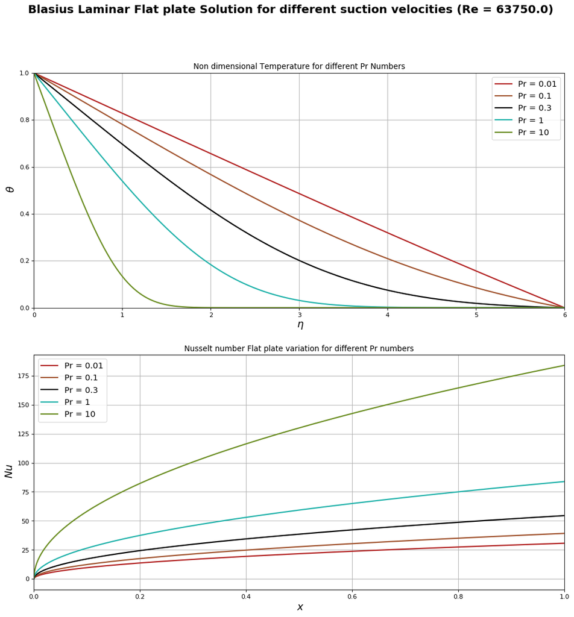

```python
# Prand Number
Pr   = [0.01,0.1,0.3,1,10]

for idx,PR in enumerate(Pr):

    # Creation of a laminar boundary layer for each vw=0
    fs.Pr = Pr[idx]
    l_bl  = laminar_boundary_layer(fp,fs,0,0)

    # Updating dictionary
    laminars_bl[str(Pr[idx])]=l_bl

# Plot
plotting.laminar_thermal(fp,fs,laminars_bl,delta_est,Pr,"Pr",4)
```

### Laminar Boundary Layer Quantities

Using inheritance in python, a laminar boundary layer with more specific attributes is going to be defined.

This class implements functions and expressions to calculate as explained above, a laminar boundary layer given a velocity suction parameter $v_w$ and a pressure gradient represented by Falkner-Skan wedge angle $\beta$

Once calculated Blasius Functions, boundary layer expressions are:

Horizontal velocity: $$ \begin{equation} \frac{u}{U} = f^{'}(\eta) \end{equation} $$

Vertical velocity: $$ \begin{equation} v = \sqrt{\frac{\nu u_e(x)}{(2-\beta)x}} \left[(1-\beta) \cdot \eta f^{'} - f(\eta) \right] \end{equation} $$

Boundary layer thickness: $$ \begin{equation} \delta = 0.994 \cdot f^{'}(\eta) \cdot x \sqrt{\frac{2}{Re_x}} \end{equation} $$

Boundary layer displacement thickness: $$ \begin{equation} \delta^{*} = x \sqrt{\frac{2-\beta}{Re_x}} \left[ \lim_{\eta \to \infty}\eta - f(\eta) \right] \end{equation} $$

Boundary layer momentum thickness $$ \begin{equation} \delta^{**} = x \sqrt{\frac{2-\beta}{Re_x}} \left[\frac{f^{''}(0,\beta) -\beta \lim_{\eta \to \infty}\eta - f(\eta)}{1+\beta} \right] \end{equation} $$

Shear Stress at the Wall:

$$ \begin{equation} \tau_{p} = \rho \cdot u_e^{2}(x) \cdot f^{''}(0,\beta) \sqrt{\frac{m+1}{2\cdot Re_x}} \end{equation} $$

the skin friction coefficient: $$ \begin{equation} c_{f} = \frac{\tau_p}{1/2 \cdot \rho \cdot u_e^{2}(x)} \end{equation} $$

and the Nusselt number:

$$ \begin{equation} Nu = \frac{q_p \cdot x}{k \cdot (T_p - T_{\infty})} = - \sqrt{\frac{Re_x}{2-\beta}} \left(\frac {d \theta}{d\eta}\right)_{\eta = 0} \end{equation} $$

## Plotting Class

```python
class plotting:

    @staticmethod
    def blasius (fp,fs,bl,delta_est):

        fig = plt.figure(num=1, figsize=(20, 15), dpi=80, facecolor='w', edgecolor='k')

        ax = fig.add_subplot(221)
        ax.plot(fp.eta,blasius_bl.f ,'r-',linewidth=2,label='f')
        ax.plot(fp.eta,blasius_bl.fd ,'b-',linewidth=2,label='f´')
        ax.plot(fp.eta,blasius_bl.fdd ,'g-',linewidth=2,label='f´´' )
        ax.set_title("Blasius Flat plate functions")
        ax.set_xlabel(r' $\eta$',fontsize=13)
        ax.set_xlim(0,4)
        ax.set_ylim(0,5)
        ax.legend(fontsize=12)
        ax.grid()

        ax = fig.add_subplot(222)
        ax.plot(blasius_bl.fd,fp.eta,color = "k",linestyle='-',linewidth=2)
        ax.set_title('Blasius Flat plate non dimensional Velocity U')
        ax.set_ylabel(r' $\eta$',fontsize=13)
        ax.set_xlabel(r' $U/u_e$',fontsize=13)
        ax.set_xlim(0,1)
        ax.set_ylim(0,6)
        ax.legend(loc = 'upper left',fontsize=12)
        ax.grid()

        #V/(nu/)-eta
        ax = fig.add_subplot(223)
        ax.plot(fp.eta*blasius_bl.fd - blasius_bl.f,fp.eta,color = "k",linestyle='-',linewidth=2)
        ax.set_title('Blasius Flat plate non dimensional Velocity V')
        ax.set_ylabel(r' $\eta$',fontsize=13)
        ax.set_xlabel(r' $V/(\nu U/2x)^{0.5}$',fontsize=12)
        ax.set_xlim(0,2)
        ax.set_ylim(0,6)
        ax.legend(loc = 'upper left',fontsize=12)
        ax.grid()

        ax = fig.add_subplot(224)
        ax.pcolor(fp.X,fp.Y, blasius_bl.u)
        ax.set_ylim(0,8*delta_est)
        ax.plot(fp.x, blasius_bl.delta,'b-',linewidth=2,label=r' $\delta$')
        ax.plot(fp.x, blasius_bl.delta_s,'r-',linewidth=2,label=r' $\delta^*$')
        ax.plot(fp.x, blasius_bl.delta_ss,'c-',linewidth=2,label=r' $\delta^{**}$')
        ax.set_title("Blasius Flat plate boundary layer")
        ax.set_xlabel(r' $x(m)$',fontsize=13)
        ax.set_ylabel(r' $y(m)$',fontsize=13)
        ax.set_xlim(0,1)
        ax.legend(fontsize=12)
        ax.grid()

    @staticmethod
    def laminar_suction_gradient (fp,fs,bl,delta_est,solutions,string,n):

        colors  = ["firebrick","sienna","black","lightseagreen","olivedrab","mediumvioletred"]

        fig = plt.figure(num=n, figsize=(20, 15), dpi=80, facecolor='w', edgecolor='k')
        if string == "vw":
            fig.suptitle("Blasius Laminar Flat plate Solution for different suction velocities (Re = %r)" %round(fs.Re,0), fontsize=18,fontweight="bold")
        elif string == "beta":
            fig.suptitle("Blasius Laminar Flat plate Solution for different pressure gradients/Falkner-Skan wedge angles (Re = %r)" %round(fs.Re,0), fontsize=18,fontweight="bold")

        #U-eta
        ax = fig.add_subplot(221)
        for idx,vw in enumerate(solutions):
            ax.plot(bl[str(vw)].fd,fp.eta,color = colors[idx],linestyle='-',linewidth=2,label=string + "=" +str(round(vw,2)))
        ax.set_title('Horixontal Non dimensional Velocity U')
        ax.set_ylabel(r' $\eta$',fontsize=13)
        ax.set_xlabel(r' $U/u_e$',fontsize=13)
        ax.set_xlim(0,1)
        ax.set_ylim(0,6)
        ax.legend(loc = 'upper left',fontsize=12)
        ax.grid()

        #V/(nu/)-eta
        ax = fig.add_subplot(222)
        for idx,vw in enumerate(solutions):
            ax.plot(fp.eta*bl[str(vw)].fd - bl[str(vw)].f,fp.eta,color = colors[idx],linestyle='-',linewidth=2,label=string + "=" +str(round(vw,2)))
        ax.set_title('Vertical Non dimensional Velocity V')
        ax.set_ylabel(r' $\eta$',fontsize=12)
        ax.set_xlabel(r' $V/(\nu U/2x)^{0.5}$',fontsize=13)
        if string == "vw":
            ax.set_xlim(-3,4)
        else:
            ax.set_xlim(0,2)
        ax.set_ylim(0,6)
        ax.legend(loc = 'upper left',fontsize=12)
        ax.grid()

        ## boundary_layer thickness_plot
        ax = fig.add_subplot(223)

        for idx,vw in enumerate(solutions):
            ax.plot(fp.x,bl[str(vw)].delta,color = colors[idx],linestyle='-',linewidth=2,label=r" $\delta$ " + string + " = "  +str(round(vw,2)))
        ax.set_title('Boundary layer height' + r' $\delta$')
        ax.set_xlabel(r' $x(m)$',fontsize=13)
        ax.set_ylabel(r' $y(m)$',fontsize=13)
        ax.set_xlim(0,1)
        ax.legend(fontsize=12)
        ax.grid()

        # Cf Plot
        ax = fig.add_subplot(224)
        for idx,vw in enumerate(solutions):
            ax.plot(fp.x, bl[str(vw)].cf,color=colors[idx],linestyle='-',linewidth=2,label= string + " = " +str(round(vw,2)) )
        ax.set_title('Skin Friction coefficient')
        ax.set_xlabel(r' $x$',fontsize=13)
        ax.set_ylabel(r' $C_f$',fontsize=13)
        ax.set_xlim(0,1)
        ax.set_ylim(0,bl[str(0)].cf[0]/10)
        ax.legend(loc = 'upper right',fontsize=12)
        ax.grid()


    @staticmethod
    def laminar_thermal(fp,fs,bl,delta_est,solutions,string,n):

        colors  = ["firebrick","sienna","black","lightseagreen","olivedrab","mediumvioletred"]

        fig = plt.figure(num=n, figsize=(15, 15), dpi=80, facecolor='w', edgecolor='k')

        fig.suptitle("Blasius Laminar Flat plate Solution for different suction velocities (Re = %r)" %round(fs.Re,0), fontsize=18,fontweight="bold")

        # Theta-eta plot
        ax = fig.add_subplot(211)
        for idx,vw in enumerate(solutions):
            ax.plot(fp.eta,bl[str(vw)].theta,color = colors[idx],linestyle='-',linewidth=2,label= string + " = " +str(round(vw,2)))
        ax.set_title('Non dimensional Temperature for different Pr Numbers')
        ax.set_ylabel(r' $\theta$',fontsize=16)
        ax.set_xlabel(r' $\eta$',fontsize=16)
        ax.set_xlim(0,fp.eta[-1])
        ax.set_ylim(0,1)
        ax.legend(loc = 'upper right',fontsize=13)
        ax.grid()

        # Nu-x Plot
        ax = fig.add_subplot(212)
        for idx,vw in enumerate(solutions):
            ax.plot(fp.x, bl[str(vw)].Nu,color=colors[idx],linestyle='-',linewidth=2,label= string + " = " +str(round(vw,2)) )
        ax.set_title('Nusselt number Flat plate variation for different Pr numbers')
        ax.set_xlabel(r' $x$',fontsize=16)
        ax.set_ylabel(r' $Nu$',fontsize=16)
        ax.set_xlim(0,fp.x[-1])
        #ax.set_ylim(0,1)
        ax.legend(loc = 'upper left',fontsize=13)
        ax.grid()
```